# AI 101

What you need to know

## What we’ll cover:

- What AI is
- Examples of AI in your life
- How AI works (conceptually)
- Why AI is (seemingly) everywhere
- Responsibly using AI
- Examples of how to put this information into action

## Goals for the Training

- Understand at a basic level what AI is
- Understand that there are different kinds of AI models
- Understand different AI models are appropriate for different tasks
- Be able to apply this information to evaluate if an AI model is probably appropriate
- Understand why the term AI has become seemingly ubiquitous
- Have a basis for further learning

How would you define AI?

“AI is whatever hasn’t been done yet.” — Tesler’s Theorem[^1]

## Defining AI

- How do you define “Intelligence”?
- Academic definitions differ and are not always helpful for practical use

AI Definition Overview[^2]

|  | Human-based | Ideal Rationality |
| --- | --- | --- |
| Reasoning-based | Systems that think like humans | Systems that think rationally |
| Behavior-based | Systems that act like humans | Systems that act rationally |

## Defining AI

AI is “an engineered or machine-based system that can, for a given set of objectives, generate outputs such as predictions, recommendations, or decisions influencing real or virtual environments. AI systems are designed to operate with varying levels of autonomy”[^3]

## Defining AI

Questions to help determine if it’s AI:

- Does the technology use data to provide predictions, recommendations, insights, or decisions?
- Does the technology augment or replace human decision-making?
- Does the company use words such as “personalized”, “tailored”, and “adaptive” in its marketing?”
- Would it be difficult or impossible to write out how a program does what it does, either because the process is opaque or because it is mathematically complex? [^4]

## Examples of AI

What are some examples of AI you interact with on a regular basis?

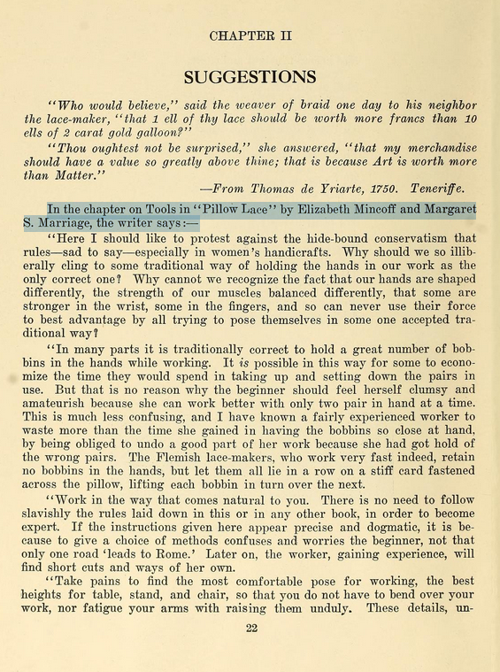

Optical Character Recognition

[figure not shown]

Video Games[^5]

Spam Filters[^6]

## How AI Works Conceptually

Models

[figure not shown]

Functional Paradigms

- Predictive/Analytical AI
- Generative AI
- Agentic AI

Lets say you need an AI to help organize some recipes:

Logicist AI

Probabilistic AI

Neurocomputational AI

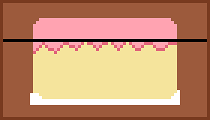

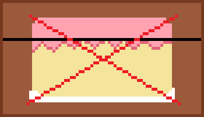

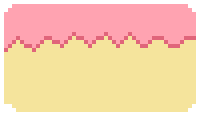

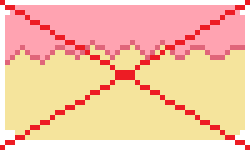

AI Model Type Overview

|  | Logicist | Probabilistic | Neurocomputational |
| --- | --- | --- | --- |
| good for: | clearly defined logic | clear factors | No clear process |
| bad at: | handling uncertainty | operating with limited /bad data or assumptions | Truth; Explainability |
| example: | email inbox rules | (some) population forecasting | chatGPT |

## Real Life Examples of Each Kind of AI

Logicist

Probabilistic

Neurocomputational

[figure not shown]

[figure not shown]

## Functional Paradigms

- Predictive and Analytical AI
  - Recognizes patterns and makes predictions[^9]
- Generative AI
  - Generates new content[^10]
- Agentic AI
  - Achieves goals by executing multi-step workflows[^11]

## Why AI Is Everywhere

What do you make of the interest in AI right now? Do you think it’s similar to anything else?

## Context

*This is not a comprehensive timeline and focuses on giving context for the current state of AI as relevant to this training.*

**TurboChamp**[^12]

**The Stochastic Neural Analog Reinforcement Calculator (SNARC)**[^13]

**Dartmouth Summer Research Project on Artificial Intelligence**[^14]

**Eliza**[^15]

**AI Winter**[^16]

**AI Winter**[^17]

**Learning representations by back-propagating errors**[^18]

**Probabilistic Reasoning in Intelligent Systems**

**A Statistical Approach to Translation**[^19]

**Software for the World Wide Web becomes Free**[^20]

**Rankdex Search Engine uses AI to prioritize sites**[^21] Google’s page-ranking algorithm was influenced by Rankdex[^22]

**Large-scale Deep Unsupervised Learning using Graphics Processors**[^23]

**Apple launches Siri**[^24]

**Attention Is All You Need**[^25]

**ChatGPT launches public preview**[^26]

**Linux Kernel adds AI agent documentation**[^27]

**AI agents become a focus for AI companies**[^28]

## Using AI

How do you use AI in your daily life, and what do you need to use those tools properly? Can you think of any non-generative AI tools you use?

## Choosing the Right Tool

- Right model for the job
  - Probabilistic vs deterministic
- Right Functional Category
  - Generative vs Agentic vs predictive/analytical
- Other things to consider
  - Security and Privacy concerns
  - Integration with existing tools
- Is AI the best solution?

Let’s say you want to write Planning 101 guide for ETDD to give to local planners to help them make better choices (and maybe sell later), but you’re on a time crunch so you want to use AI to help you.

What model types and functional categories could you use and how?

## Using the Tool Safely - General Considerations

- The tool might work differently than you expect
- Bias
- Legal Grey Areas
  - AI Notetakers[^29]
  - State laws
  - Mostly applying existing laws to AI
- Remember that it is a tool

## Using the Tool Safely - Generative and Agentic AI

- Malware[^30]
- Over reliance on the tool
- Difficult to assess quality[^31]
- Accelerating how fast you can mess up
- The tool doing something you didn’t tell it to do[^32]
- Mental health concerns[^33]

## Using the Tool Safely - Interacting With Others

- Lost of trust with communities
- Loss of quality
- Privacy Rights[^34]
- Public Opinion

## Broader Concerns with Societal Use of AI

- Software Supply Chain Issues
  - Malware
  - Negative Impacts to Open Source Software[^35]
- Copyright[^36]
- Loss of entry-level positions
- Loss of Trust[^37]

Thinking about the Planning 101 guide and how you might use AI to help you, what are some concerns you might have with the different ways you could use AI? Are there any potential harms you might be able to mitigate?

## Using the Tool Responsibly

- You are the one using AI, even agentic AI
- Automation Bias[^38]
- Balancing Use
- Make sure you understand and respect the limitations of tools
  - Don’t use AI search results without verifying with a legitimate source
  - Don’t give agentic AI access to anything you’re not willing to lose

## Putting It In Action / Hypotheticals

Let’s say you want to predict the future population of Knoxville. A company is offering to use AI to forecast the population for the next ten years.

What kind of model(s) or functional categories would *not* be appropriate?

What could you ask them to evaluate if their methods work?

Would you feel confident in your answer, or would you want to ask someone who is more familiar with forecasting?

## Thank you

## References

2023. https://www.newyorkmyc.org/ai-generated-mushroom-books-life-and-death/.

2025. https://news.bloomberglaw.com/litigation/wiretap-suits-pit-old-privacy-laws-against-new-ai-technology.

2026. https://www.ibm.com/think/topics/history-of-artificial-intelligence.

n.d. https://commons.wikimedia.org/wiki/File:Email-spam-sample_(cropped).png.

n.d. https://owasp.org/www-project-top-10-for-large-language-model-applications/.

n.d. https://owasp.org/www-project-citizen-development-top10-security-risks/content/2022/en/CD-SEC-01-Blind-Trust.html.

In *Computerworld*. n.d. https://www.computerworld.com/article/4041849/enterprise-note-taking-apps-face-legal-scrutiny-as-otter-hit-with-privacy-suit.html.

In *NVIDIA Technical Blog*. 2025. https://developer.nvidia.com/blog/how-code-execution-drives-key-risks-in-agentic-ai-systems/.

*METR Blog*, August 2026. https://metr.org/blog/2026-08-26-openai-hugging-face-incident-investigation/.

Abram, Zara. “Understanding ‘AI Psychosis’.” *Monitor on Psychology* 57, no. 6 (2026): 58. https://www.apa.org/monitor/2026/09/ai-psychosis.

Bergmann, Dave. *The ELIZA Effect: Avoiding Emotional Attachment to AI Coworkers | IBM*. 2025. https://www.ibm.com/think/insights/eliza-effect-avoiding-emotional-attachment-to-ai.

Bringsjord, Selmer, and Naveen Sundar Govindarajulu. “Artificial Intelligence.” In *The Stanford Encyclopedia of Philosophy*, Spring 2025, edited by Edward N. Zalta and Uri Nodelman. [Https://plato.stanford.edu/archives/spr2025/entries/artificial-intelligence/](https://plato.stanford.edu/archives/spr2025/entries/artificial-intelligence/); Metaphysics Research Lab, Stanford University, 2025.

Chugani, Vinod. “AI Winter: Understanding the Cycles of AI Development.” In *Data Camp*. 2025. https://www.datacamp.com/blog/ai-winter.

Clark, Liat, and Ian Steadman. “Remembering Alan Turing: From Codebreaking to AI, Turing Made the World What It Is Today.” *Wired*, 2017. https://www.wired.com/story/turing-contributions/.

Ferrara, Emilio. *The Generative AI Paradox: GenAI and the Erosion of Trust, the Corrosion of Information Verification, and the Demise of Truth*. January 2026. https://arxiv.org/html/2601.00306v1.

Finio, Amanda Downie, Teaganne Finn. *Agentic AI Vs. Generative AI | IBM*. 2025. https://www.ibm.com/think/topics/agentic-ai-vs-generative-ai.

Friedland, Alex. “What Are Generative AI, Large Language Models, and Foundation Models?” In *Center for Security and Emerging Technology*. 2023. https://cset.georgetown.edu/article/what-are-generative-ai-large-language-models-and-foundation-models/.

Goodin, Dan. “Claude, Codex, and Hermes Installed Unowned Code Inside Corporate Networks.” In *Ars Technica*. 2026. https://arstechnica.com/security/2026/08/claude-codex-and-hermes-installed-unowned-code-inside-corporate-networks/.

Levin, Sasha. *[RFC 0/2] Add AI Coding Assistant Configuration to Linux Kernel*. 2025. https://lkml.org/lkml/2025/7/25/988.

Namco. *English: Pac-Man Approaching a Row of Three Dots.* 2024. https://commons.wikimedia.org/wiki/File:Pac-Man_eating_dots.svg.

Office, United States Copyright. *Copyright and Artificial Intelligence Part 2: Copyrightability*. 2025. https://www.copyright.gov/ai/Copyright-and-Artificial-Intelligence-Part-2-Copyrightability-Report.pdf.

Office, United States Copyright. *Copyright and Artificial Intelligence Part 3: Generative AI Training*. May 2025. https://www.copyright.gov/ai/Copyright-and-Artificial-Intelligence-Part-3-Generative-AI-Training-Report-Pre-Publication-Version.pdf.

*Programmers at Work: Interviews Wit 19 Programmers Who Shaped the Computer Industry*. Repr. with new additions. Microsoft Pr, 1989.

published, Craig Hale. “Microsoft Admits an Office Bug Exposed Confidential User Emails to Copilot.” In *TechRadar*. 2026. https://www.techradar.com/pro/security/microsoft-admits-an-office-bug-exposed-confidential-user-emails-to-copilot.

Romeo, Giuseppe, and Daniela Conti. “Exploring Automation Bias in Human–AI Collaboration: A Review and Implications for Explainable AI.” *AI & SOCIETY* 41, no. 1 (2026): 259–78. https://doi.org/10.1007/s00146-025-02422-7.

San José’s Information Technology Department: Digital Privacy Office, City of. *AI Handbook*. 2024. https://www.sanjoseca.gov/home/showpublisheddocument/109904/638463850657330000.

Shambaugh, Scott. “An AI Agent Published a Hit Piece on Me.” In *The Shamblog*. 2026. https://theshamblog.com/an-ai-agent-published-a-hit-piece-on-me/.

Tabassi, Elham. *Artificial Intelligence Risk Management Framework (AI RMF 1.0)*. National Institute of Standards; Technology (U.S.), 2023. https://doi.org/10.6028/NIST.AI.100-1.

“Tesler’s Theorem and Other Adages and Coinages.” In *Larry Tesler*. n.d. https://www.nomodes.com/larry-tesler-consulting/adages-and-coinages.

Vaswani, Ashish, Noam Shazeer, Niki Parmar, et al. *Attention Is All You Need*. no. arXiv:1706.03762 (August 2023). https://doi.org/10.48550/arXiv.1706.03762.

Wolf, Ashley. “Welcome to the Eternal September of Open Source. Here’s What We Plan to Do for Maintainers.” In *The GitHub Blog*. 2026. https://github.blog/open-source/maintainers/welcome-to-the-eternal-september-of-open-source-heres-what-we-plan-to-do-for-maintainers/.

## Policy

[figure not shown]